# Outbreak Detectives: Can You Stop the Spread?

R-Ladies+ Melbourne

# Emergency Alert

Several local hospitals have reported an unusual increase in sick students from the same school.

Students from two classrooms have presented with a range of symptoms, and the number of cases is continuing to grow.

Your team has joined the **Global Outbreak Investigation Unit**.

Your job is to work out what is happening.

Do not diagnose the outbreak yet. Follow the evidence.

Possible causes include:

- Influenza A
- COVID-19
- Zombie Virus A
- Malaria
- RSV (Respiratory syncytial virus)
- Rhinovirus
- Human metapneumovirus (HMPV)
- Toxoplasmosis

Your job is to follow the evidence.

# 1. Hospital records have arrived

First, open the patient file.

```r
patients_raw <- load_patients()
```

Take a look.

```r
head(patients_raw)
```

```
## # A tibble: 6 × 19
##   patient_id first_name class   age sex    temperature_c hours_to_symptoms
##   <chr>      <chr>      <chr> <dbl> <chr>          <dbl>             <dbl>
## 1 P01        Alex       9A       16 female          37.3               72
## 2 P02        Amelia     9A       13 F               37.8              121
## 3 P03        Ari        9A       15 male            37.5              191.
## 4 P04        Bailey     9A       13 Female          38.3              110.
## 5 P05        Charlie    9A       14 male            37.7              125.
## 6 P06        Chloe      9A       13 Male            37.4              181.
## # ℹ 12 more variables: hospitalised <chr>, case_status <chr>, fever <chr>,
## #   cough <chr>, sore_throat <chr>, headache <chr>, muscle_aches <chr>,
## #   vomiting <chr>, diarrhoea <chr>, loss_of_smell <chr>, bleeding <chr>,
## #   confusion <chr>
```

```r
names(patients_raw)
```

```
##  [1] "patient_id"        "first_name"        "class"
##  [4] "age"               "sex"               "temperature_c"
##  [7] "hours_to_symptoms" "hospitalised"      "case_status"
## [10] "fever"             "cough"             "sore_throat"
## [13] "headache"          "muscle_aches"      "vomiting"
## [16] "diarrhoea"         "loss_of_smell"     "bleeding"
## [19] "confusion"
```

### What do you notice?

- What does one row represent?
- What information do we have about each student?
- Can you spot anything messy?

# 2. Clean the data

The hospital entered the records very quickly.

For example:

`Yes`, `YES`, `yes` and `Y`

all mean the same thing.

Instead of fixing every value ourselves, we can use a function.

```r
patients <- clean_data(patients_raw)
```

Did it work?

```r
count_cases(patients)
```

```
## # A tibble: 2 × 2
##   case_status students
##   <chr>          <int>
## 1 Sick              71
## 2 Well              24
```

### Why clean data?

Computers need us to be consistent.  
If `"Yes"` and `"YES"` are written differently, R may think they are different answers.

# 3. How many students are sick?

```r
count_cases(patients)
```

```
## # A tibble: 2 × 2
##   case_status students
##   <chr>          <int>
## 1 Sick              71
## 2 Well              24
```

Now look at the students with the highest temperatures.

```r
show_sickest(patients)
```

```
## # A tibble: 6 × 4
##   patient_id first_name temperature_c hospitalised
##   <chr>      <chr>              <dbl> <chr>
## 1 P08        Dev                 38.4 Yes
## 2 P16        Isaac               38.4 Yes
## 3 P31        Sam                 38.4 Yes
## 4 P04        Bailey              38.3 No
## 5 P13        Harper              38.3 Yes
## 6 P23        Maya                38.3 No
```

### Your turn

What do you notice about their temperatures?

# 4. What symptoms are most common?

```r
symptom_table(patients)
```

```
## # A tibble: 8 × 2
##   symptom           n
##   <chr>         <int>
## 1 cough            48
## 2 sore_throat      36
## 3 fever            34
## 4 muscle_aches     27
## 5 headache         21
## 6 diarrhoea        18
## 7 vomiting         14
## 8 loss_of_smell     3
```

Now make a graph.

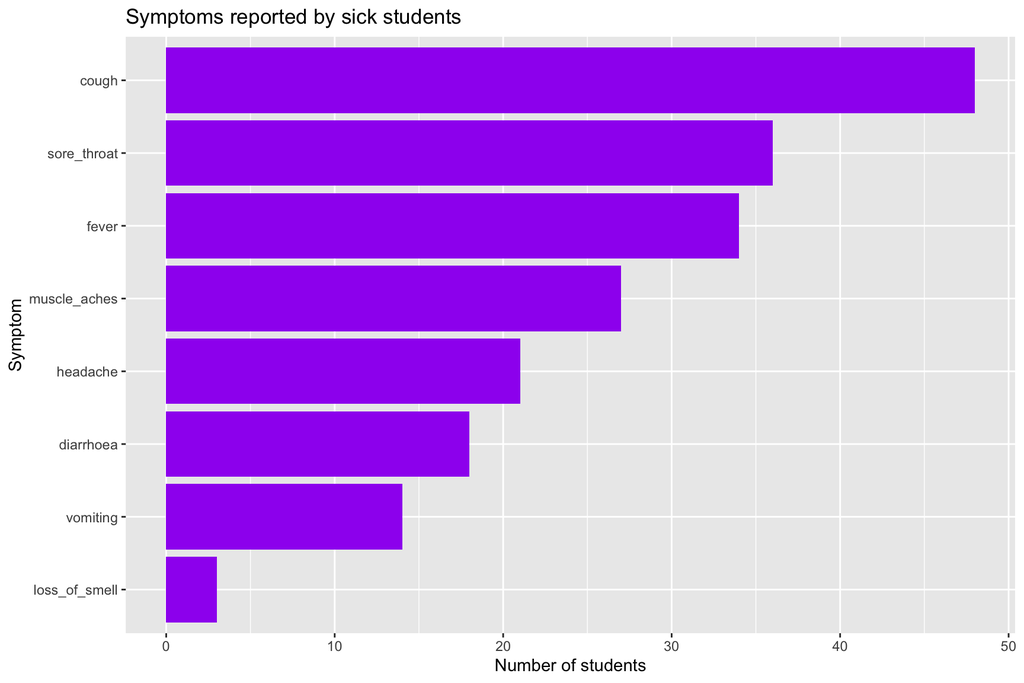

```r
symptoms <- symptom_table(patients)

ggplot(symptoms, aes(
  x = n,
  y = reorder(symptom, n)
)) +
  geom_col(fill = "purple") +
  labs(
    title = "Symptoms reported by sick students",
    x = "Number of students",
    y = "Symptom"
  )
```

### Try editing the graph

Change `"purple"` to another colour and run the code again.

You can also change the words inside `title =`, `x =` and `y =`.

### Think like a disease detective

Which symptoms stand out?

Does this help rule out any diseases?

# 5. Do sick students have higher temperatures?

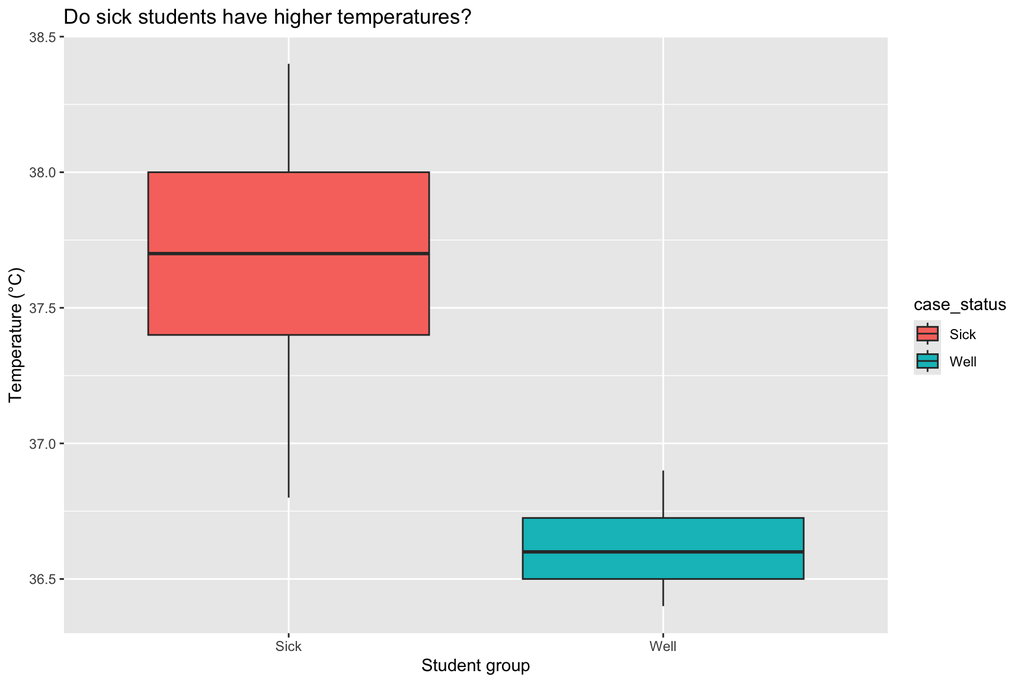

```r
ggplot(patients, aes(
  x = case_status,
  y = temperature_c,
  fill = case_status
)) +
  geom_boxplot() +
  labs(
    title = "Do sick students have higher temperatures?",
    x = "Student group",
    y = "Temperature (°C)"
  )
```

### Try editing the graph

Inside `aes()`, change:

```r
fill = case_status
```

to:

```r
colour = case_status
```

What changes?

### What do you notice?

Compare the middle of the two boxplots.

# 6. How quickly did students become sick?

```r
show_onset(patients)
```

```
## # A tibble: 1 × 3
##   sick_students typical_temperature typical_hours_to_symptoms
##           <int>               <dbl>                     <dbl>
## 1            71                37.7                       116
```

The time between being exposed and becoming sick can be an important clue.

# 7. New evidence: locations

A second file has arrived.

```r
locations <- load_locations()
```

We need information from **both files**.

```r
investigation <- combine_evidence(
  patients,
  locations
)
```

Now find the locations with the most illness.

```r
location_table(investigation)
```

```
## # A tibble: 9 × 4
##   location                               students  sick attack_rate
##   <chr>                                     <int> <int>       <dbl>
## 1 Before-school swimming practice              15    15       1
## 2 Lunch area                                   15    15       1
## 3 Art class                                    10    10       1
## 4 International airport / return flight         1     1       1
## 5 Classroom 9A                                 31    19       0.613
## 6 Hockey training                              20    11       0.55
## 7 Classroom 9B                                 12     0       0
## 8 Lunch courtyard                              24     0       0
## 9 Swimming practice - did not enter pool       15     0       0
```

And plot them.

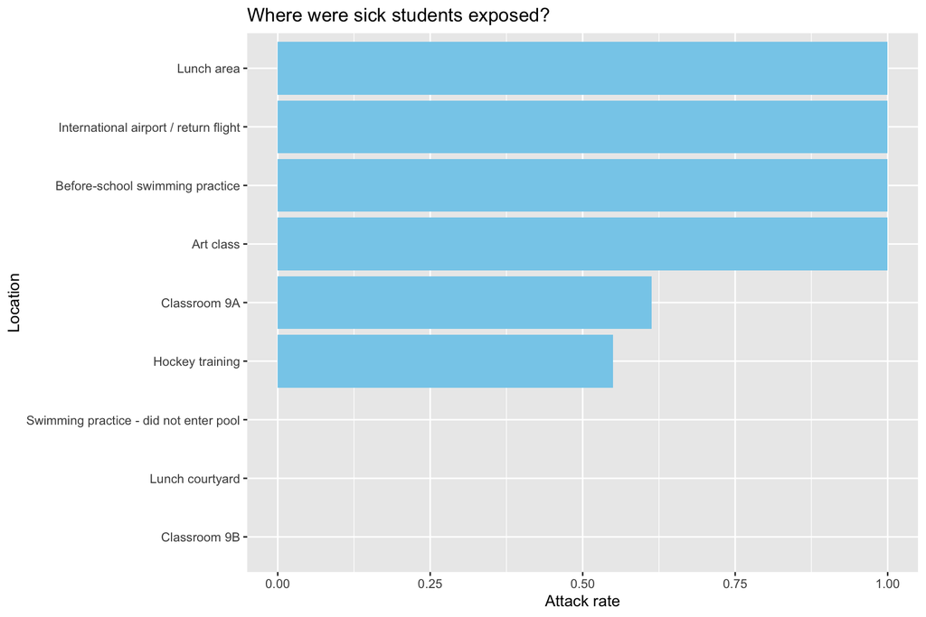

```r
locations_summary <- location_table(investigation)

ggplot(locations_summary, aes(
  x = attack_rate,
  y = reorder(location, attack_rate)
)) +
  geom_col(fill = "skyblue") +
  labs(
    title = "Where were sick students exposed?",
    x = "Attack rate",
    y = "Location"
  )
```

### Try editing the graph

Change `"skyblue"` to `"orange"`, `"green"` or another colour.

Then try changing the graph title.

### What does this tell us?

Does one location or activity stand out?

Could there be more than one explanation?

# 8. Make a preliminary diagnosis

Open the disease clue sheet.

```r
disease_clues <- load_disease_clues()

disease_clues
```

```
## # A tibble: 9 × 8
##   disease     fever cough vomiting diarrhoea confusion_or_bleeding typical_onset
##   <chr>       <chr> <chr> <chr>    <chr>     <chr>                 <chr>
## 1 RSV (Respi… Low … Very… Uncommon Rare      Rare                  2–8 days
## 2 Human meta… Poss… Comm… Possible Rare      Rare                  3–6 days
## 3 Influenza A High  Comm… Sometim… Uncommon  Rare                  1–4 days
## 4 COVID-19    Poss… Comm… Sometim… Possible  Rare                  2–5 days
## 5 Rhinovirus  Usua… Comm… Rare     Rare      Rare                  1–3 days
## 6 Cryptospor… Poss… Rare  Common   Very com… Rare                  1–12 days; a…
## 7 Toxoplasmo… Poss… Rare  Rare     Rare      Rare                  Variable
## 8 Eimeriosis  Vari… Rare  Possible Possible  Rare                  Variable
## 9 Malaria (P… Comm… Rare  Possible Possible  Possible              Usually 7+ d…
## # ℹ 1 more variable: common_exposure <chr>
```

Before you see the laboratory results, decide:

1. What disease do you think is spreading?
2. What evidence supports your answer?
3. Is there anything unusual about two of the sick students?

# 9. Breaking News: sequencing results

Patient records have arrived from several hospitals.

The records were assembled quickly by different staff members, so some values may be written inconsistently.

Most of the students who became sick have visited hospital at some stage during the investigation.

```r
show_tree(
  sample_colour = "red",
  reference_colour = "grey30",
  title = "Which reference is closest to the outbreak samples?"
)
```

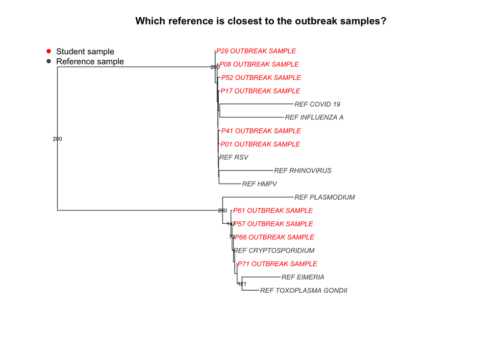

### Read the tree

A tree can tell us which samples are genetically similar.

It **cannot** prove exactly who infected whom.

# 10. Contact tracing

Interviewers have now told us who spent time together.

```r
contacts <- load_contacts()
```

How many separate groups are in the contact data?

```r
network_groups(contacts)
```

[output not shown]

Now draw the network.

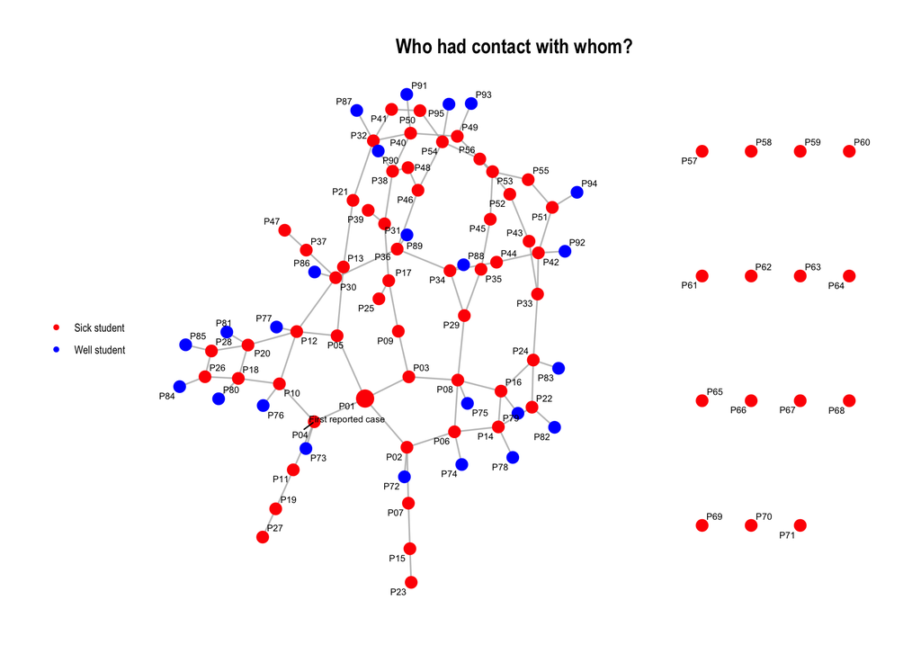

```r
network <- show_network(
  contacts,
  patients,
  sick_colour = "red",
  well_colour = "blue",
  title = "Who had contact with whom?"
)

network
```

### Investigate the network

# 11. Final diagnosis

Your team must now give the outbreak response team its answer.

### Main outbreak

What is the most likely disease?

### Give three pieces of evidence

You could use:

- symptoms
- time to illness
- locations
- sequencing
- contact network

# The bigger lesson

Real outbreak investigations combine different types of evidence.

No single graph gives us the whole answer.

Today you used:

**data + coding + epidemiology + genomics + networks**

to solve an outbreak.